# Nigeria Food Consumption

#### Consumption of Vitamin A rich foods: orange-flesh sweet potato

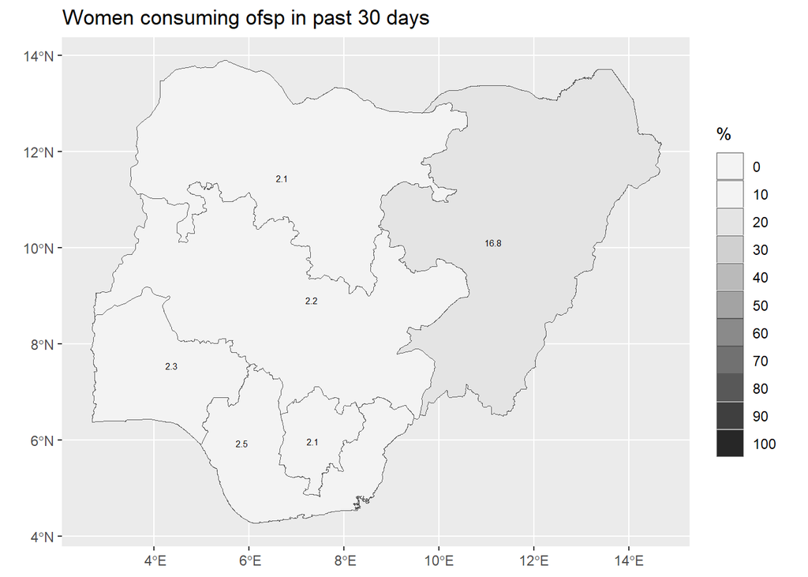

```r
ggplot(vect_gpz_geo_NFCMS) +
  geom_spatvector(aes(fill = WRA_ofsp_pc_cons_fig12)) +
  geom_spatvector_text(aes(label = WRA_ofsp_pc_cons_fig12), size = 2) +
  scale_fill_stepsn(
    n.breaks = 10,
    limits = c(0, 100),
    colours = hcl.colors(palette = "Grays", 10, rev = T),
    guide = "legend",
    na.value = "pink",
    labels = scales::comma
  ) +
  labs(title = "Women consuming ofsp in past 30 days", fill = "%") +
  theme(
    plot.title = element_markdown(),
    legend.title = element_markdown(),
    axis.title = element_blank()
  )
```

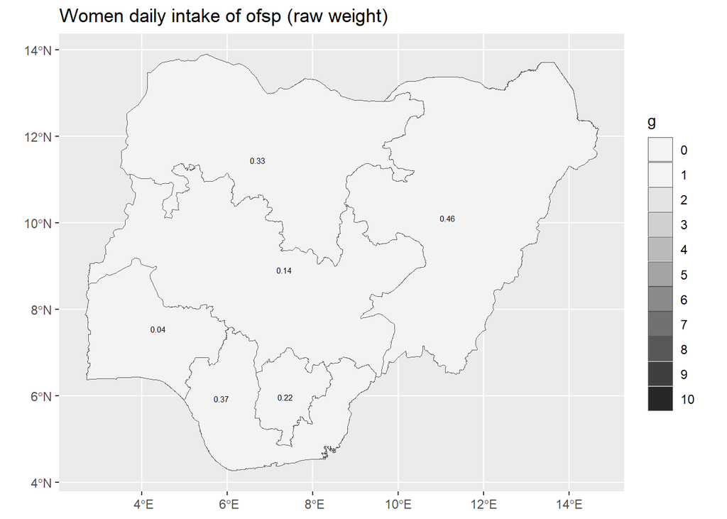

```r
ggplot(vect_gpz_geo_NFCMS) +
  geom_spatvector(aes(fill = WRA_ofsp_daily_128)) +
  geom_spatvector_text(aes(label = WRA_ofsp_daily_128), size = 2) +
  scale_fill_stepsn(
    n.breaks = 10,
    limits = c(0, 10),
    colours = hcl.colors(palette = "Grays", 10, rev = T),
    guide = "legend",
    na.value = "pink",
    labels = scales::comma
  ) +
  labs(title = "Women daily intake of ofsp (raw weight)", fill = "g") +
  theme(
    plot.title = element_markdown(),
    legend.title = element_markdown(),
    axis.title = element_blank()
  )
```

The average daily consumption was minimal, suggesting that those women who had tried OFSP did not consume the sweet potato frequently, and/or consumed only small portions.

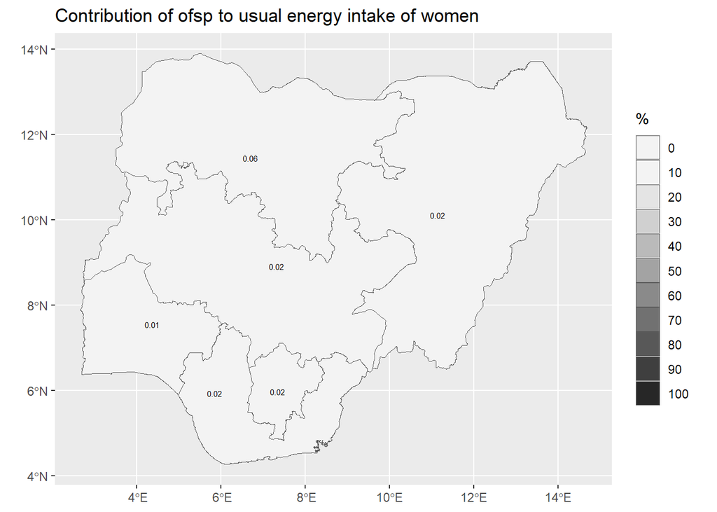

```r
ggplot(vect_gpz_geo_NFCMS) +
  geom_spatvector(aes(fill = WRA_ofsp_pc_energy_130)) +
  geom_spatvector_text(aes(label = WRA_ofsp_pc_energy_130), size = 2) +
  scale_fill_stepsn(
    n.breaks = 10,
    limits = c(0, 100),
    colours = hcl.colors(palette = "Grays", 10, rev = T),
    guide = "legend",
    na.value = "pink",
    labels = scales::comma
  ) +
  labs(title = "Contribution of ofsp to usual energy intake of women", fill = "%") +
  theme(
    plot.title = element_markdown(),
    legend.title = element_markdown(),
    axis.title = element_blank()
  )
```

Due to the low consumption quantities the contribution of OFSP to energy intake was practically 0 in all zones.

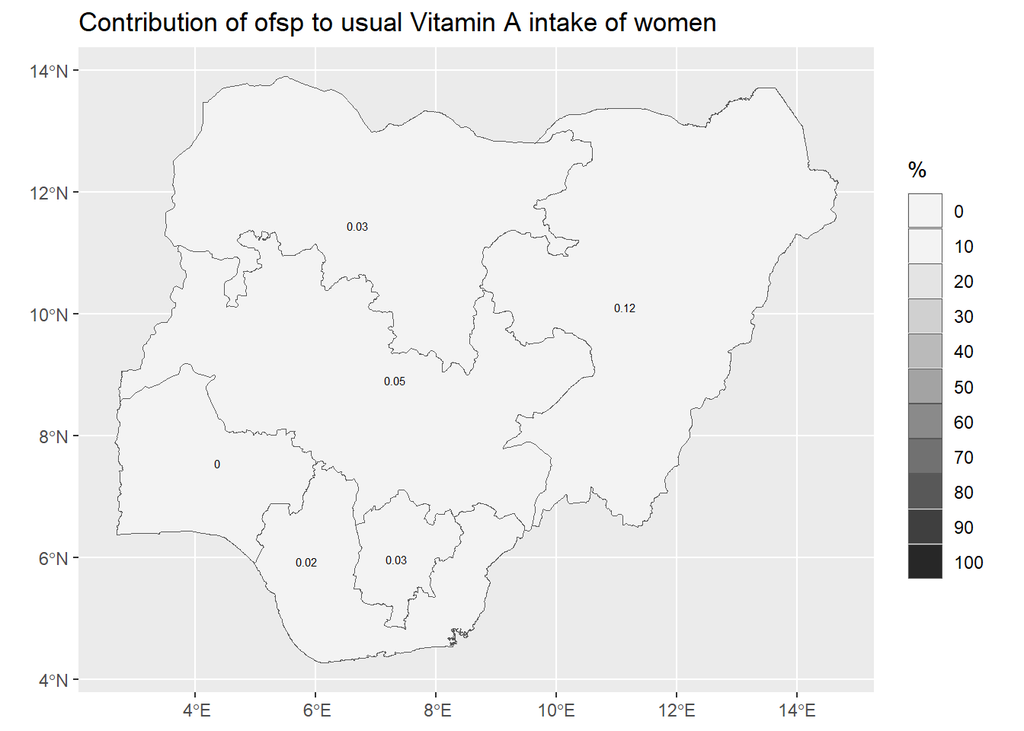

```r
ggplot(vect_gpz_geo_NFCMS) +
  geom_spatvector(aes(fill = WRA_ofsp_pc_vit_A_132)) +
  geom_spatvector_text(aes(label = WRA_ofsp_pc_vit_A_132), size = 2) +
  scale_fill_stepsn(
    n.breaks = 10,
    limits = c(0, 100),
    colours = hcl.colors(palette = "Grays", 10, rev = T),
    guide = "legend",
    na.value = "pink",
    labels = scales::comma
  ) +
  labs(title = "Contribution of ofsp to usual Vitamin A intake of women", fill = "%") +
  theme(
    plot.title = element_markdown(),
    legend.title = element_markdown(),
    axis.title = element_blank()
  )
```

Due to the low consumption quantities the contribution of OFSP to Vitamin A intake was also insignificant in all zones.

#### Consumption of Vitamin A rich foods: yellow maize

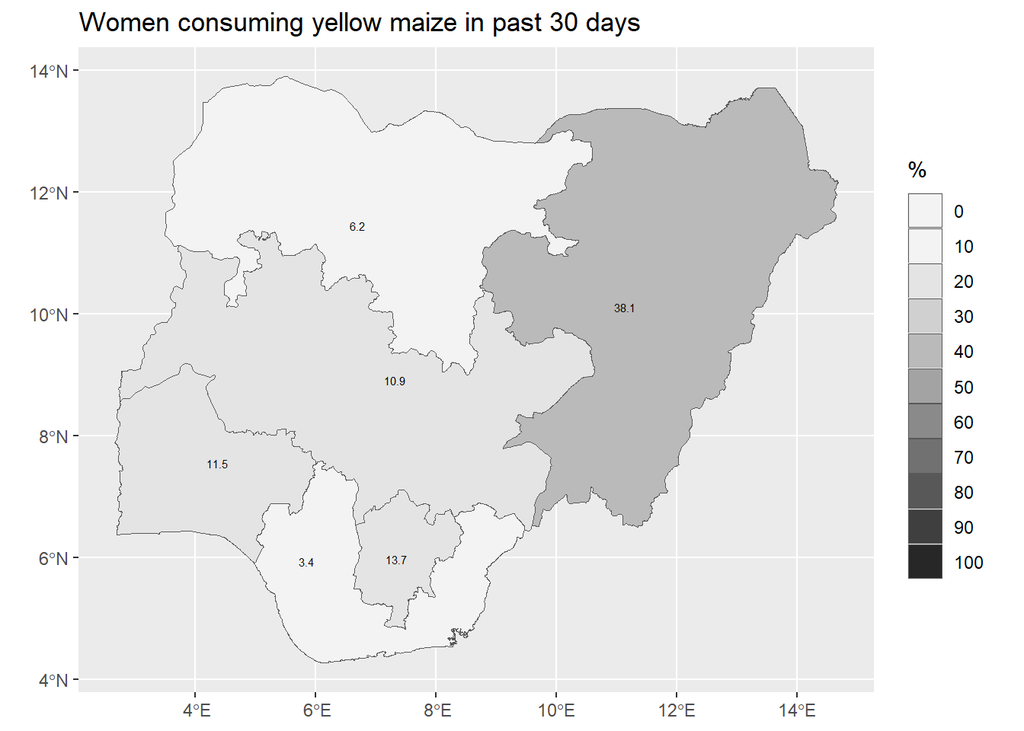

```r
ggplot(vect_gpz_geo_NFCMS) +
  geom_spatvector(aes(fill = WRA_maiz_vit_A_pc_cons_fig14)) +
  geom_spatvector_text(aes(label = WRA_maiz_vit_A_pc_cons_fig14), size = 2) +
  scale_fill_stepsn(
    n.breaks = 10,
    limits = c(0, 100),
    colours = hcl.colors(palette = "Grays", 10, rev = T),
    guide = "legend",
    na.value = "pink",
    labels = scales::comma
  ) +
  labs(title = "Women consuming yellow maize in past 30 days", fill = "%") +
  theme(
    plot.title = element_markdown(),
    legend.title = element_markdown(),
    axis.title = element_blank()
  )
```

The proportion of women having eaten yellow maize in the previous month was substantial in North East, moderate in South East, South West and North Central, but low in South South and North West.

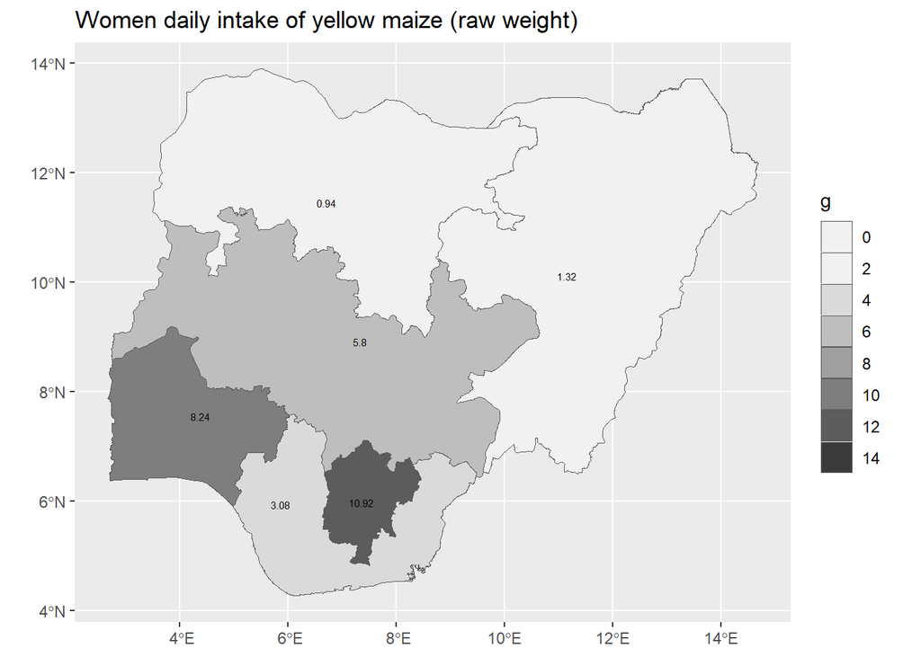

```r
ggplot(vect_gpz_geo_NFCMS) +
  geom_spatvector(aes(fill = WRA_maiz_vit_A_daily_134)) +
  geom_spatvector_text(aes(label = WRA_maiz_vit_A_daily_134), size = 2) +
  scale_fill_stepsn(
    n.breaks = 10,
    limits = c(0, 15),
    colours = hcl.colors(palette = "Grays", 10, rev = T),
    guide = "legend",
    na.value = "pink",
    labels = scales::comma
  ) +
  labs(title = "Women daily intake of yellow maize (raw weight)", fill = "g") +
  theme(
    plot.title = element_markdown(),
    legend.title = element_markdown(),
    axis.title = element_blank()
  )
```

As with yellow cassava, despite a large proportion of the women having tried yellow maize in North East, the daily intake was minimal, whereas larger quantities were consumed in South East and South West. These amounts are still very small when compared to overall daily carbohydrate consumption.

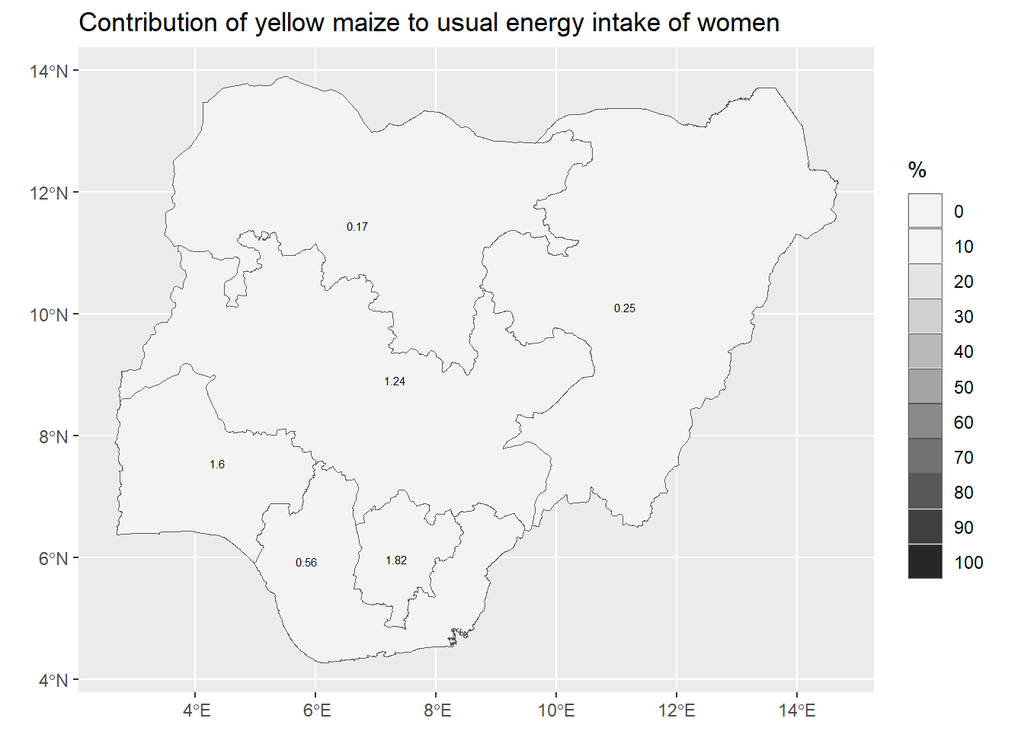

```r
ggplot(vect_gpz_geo_NFCMS) +
  geom_spatvector(aes(fill = WRA_maiz_vit_A_pc_energy_136)) +
  geom_spatvector_text(aes(label = WRA_maiz_vit_A_pc_energy_136), size = 2) +
  scale_fill_stepsn(
    n.breaks = 10,
    limits = c(0, 100),
    colours = hcl.colors(palette = "Grays", 10, rev = T),
    guide = "legend",
    na.value = "pink",
    labels = scales::comma
  ) +
  labs(title = "Contribution of yellow maize to usual energy intake of women", fill = "%") +
  theme(
    plot.title = element_markdown(),
    legend.title = element_markdown(),
    axis.title = element_blank()
  )
```

The contribution of yellow maize to energy intakes was below 1% in North East, North West and South South zones.

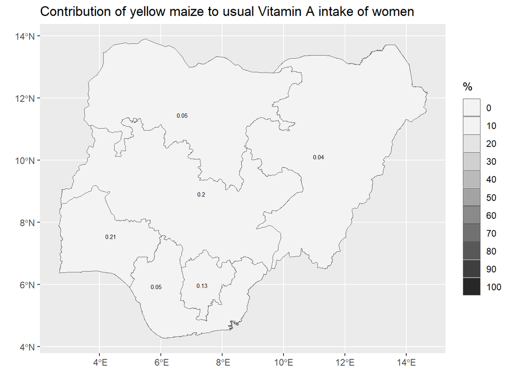

```r
ggplot(vect_gpz_geo_NFCMS) +
  geom_spatvector(aes(fill = WRA_maiz_vit_A_pc_vit_A_138)) +
  geom_spatvector_text(aes(label = WRA_maiz_vit_A_pc_vit_A_138), size = 2) +
  scale_fill_stepsn(
    n.breaks = 10,
    limits = c(0, 100),
    colours = hcl.colors(palette = "Grays", 10, rev = T),
    guide = "legend",
    na.value = "pink",
    labels = scales::comma
  ) +
  labs(title = "Contribution of yellow maize to usual Vitamin A intake of women", fill = "%") +
  theme(
    plot.title = element_markdown(),
    legend.title = element_markdown(),
    axis.title = element_blank()
  )
```

The contribution of yellow maize to Vitamin A intakes was practically non-existent in all zones.

### Vitamin C intake (NFCMS, 2021)

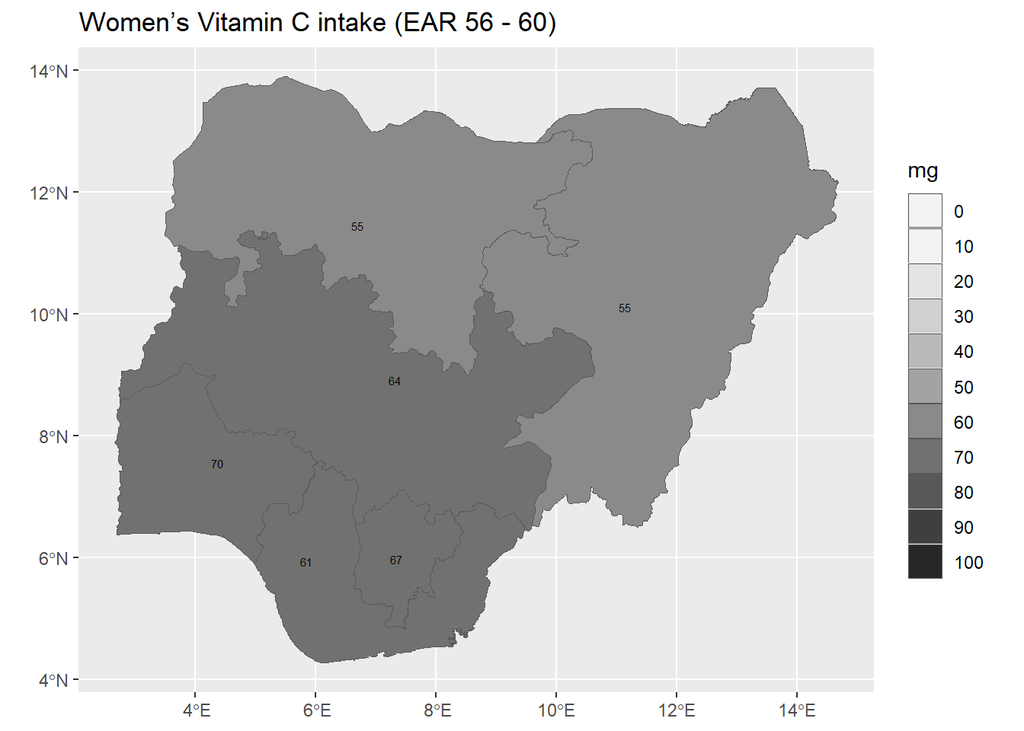

```r
ggplot(vect_gpz_geo_NFCMS) +
  geom_spatvector(aes(fill = VITC_IN_W_83)) +
  geom_spatvector_text(aes(label = VITC_IN_W_83), size = 2) +
  scale_fill_stepsn(
    n.breaks = 10,
    limits = c(0, 100),
    colours = hcl.colors(palette = "Grays", 10, rev = T),
    guide = "legend",
    na.value = "pink",
    labels = scales::comma
  ) +
  labs(title = "Women's Vitamin C intake (EAR 56 - 60)", fill = "mg") +
  theme(
    plot.title = element_markdown(),
    legend.title = element_markdown(),
    axis.title = element_blank()
  )
```

The average intake is above the recommended intake for non-pregnant women in four zones: the three southern zones and North Central, and below the recommended intake in North East and North West.

### Vitamin B1 intake (NFCMS, 2021)

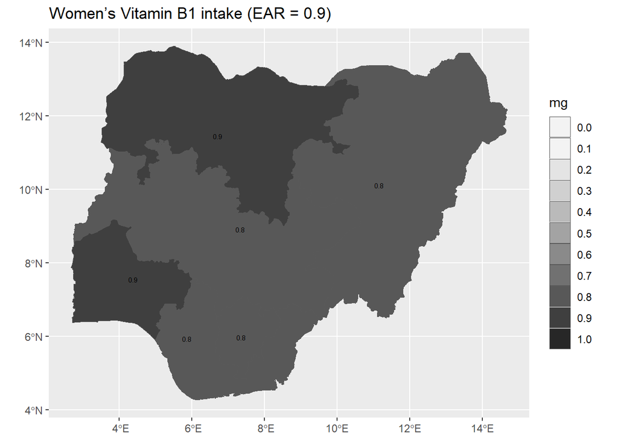

```r
ggplot(vect_gpz_geo_NFCMS) +
  geom_spatvector(aes(fill = VITB1_IN_W_87)) +
  geom_spatvector_text(aes(label = VITB1_IN_W_87), size = 2) +
  scale_fill_stepsn(
    n.breaks = 10,
    limits = c(0, 1),
    colours = hcl.colors(palette = "Grays", 10, rev = T),
    guide = "legend",
    na.value = "pink",
    labels = scales::comma
  ) +
  labs(title = "Women's Vitamin B1 intake (EAR = 0.9)", fill = "mg") +
  theme(
    plot.title = element_markdown(),
    legend.title = element_markdown(),
    axis.title = element_blank()
  )
```

Vitamin B1 intake is highest in North West and South West zones. The average intake is at the recommended intake for non-pregnant women in those two zones, and below the requirements in the other four zones.

### Vitamin B2 intake (NFCMS, 2021)

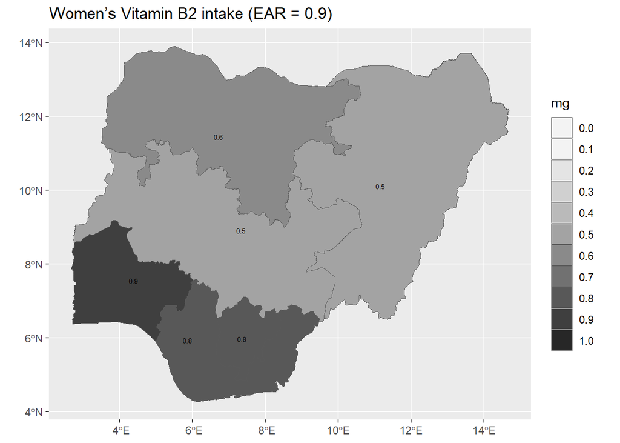

```r
ggplot(vect_gpz_geo_NFCMS) +
  geom_spatvector(aes(fill = VITB2_IN_W_91)) +
  geom_spatvector_text(aes(label = VITB2_IN_W_91), size = 2) +
  scale_fill_stepsn(
    n.breaks = 10,
    limits = c(0, 1),
    colours = hcl.colors(palette = "Grays", 10, rev = T),
    guide = "legend",
    na.value = "pink",
    labels = scales::comma
  ) +
  labs(title = "Women's Vitamin B2 intake (EAR = 0.9)", fill = "mg") +
  theme(
    plot.title = element_markdown(),
    legend.title = element_markdown(),
    axis.title = element_blank()
  )
```

Vitamin B2 intake is highest in the South West zone. This zone is the only zone where average intake is at the recommended intake for non-pregnant women. Vitamin B2 intake is below the EAR in the other five zones.

### Vitamin B9 intake (NFCMS, 2021)

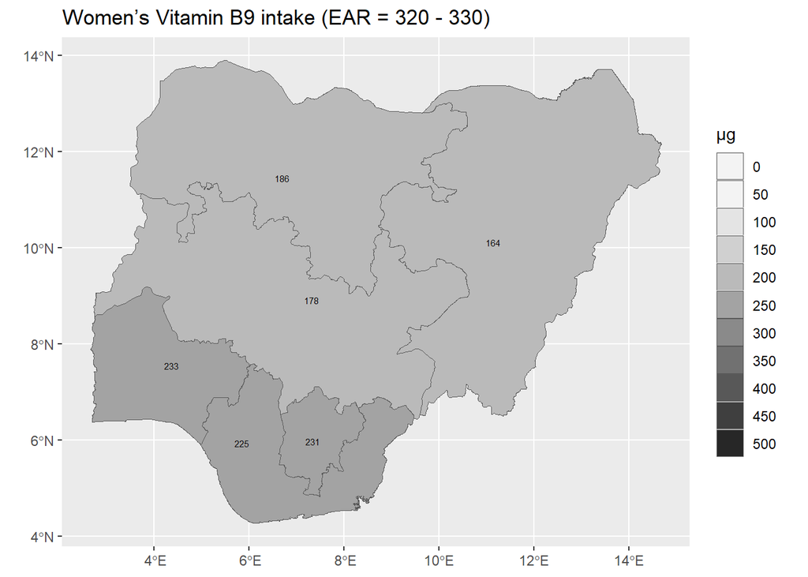

```r
ggplot(vect_gpz_geo_NFCMS) +
  geom_spatvector(aes(fill = VITB9_IN_W_95)) +
  geom_spatvector_text(aes(label = VITB9_IN_W_95), size = 2) +
  scale_fill_stepsn(
    n.breaks = 10,
    limits = c(0, 500),
    colours = hcl.colors(palette = "Grays", 10, rev = T),
    guide = "legend",
    na.value = "pink",
    labels = scales::comma
  ) +
  labs(title = "Women's Vitamin B9 intake (EAR = 320 - 330)", fill = "µg") +
  theme(
    plot.title = element_markdown(),
    legend.title = element_markdown(),
    axis.title = element_blank()
  )
```

Vitamin B9 (folate) intake is highest in the three southern zones.

However, the average intake is below the recommended intake for non-pregnant women in **all** zones.

### Vitamin B12 intake (NFCMS, 2021)

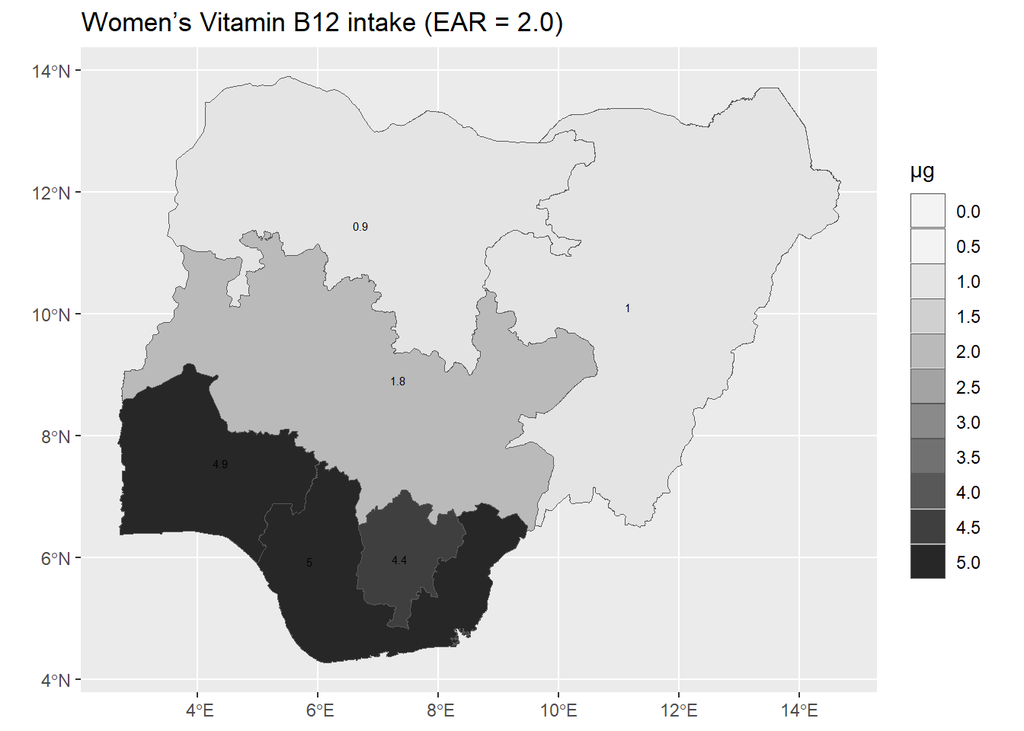

```r
ggplot(vect_gpz_geo_NFCMS) +
  geom_spatvector(aes(fill = VITB12_IN_W_99)) +
  geom_spatvector_text(aes(label = VITB12_IN_W_99), size = 2) +
  scale_fill_stepsn(
    n.breaks = 10,
    limits = c(0, 5),
    colours = hcl.colors(palette = "Grays", 10, rev = T),
    guide = "legend",
    na.value = "pink",
    labels = scales::comma
  ) +
  labs(title = "Women's Vitamin B12 intake (EAR = 2.0)", fill = "µg") +
  theme(
    plot.title = element_markdown(),
    legend.title = element_markdown(),
    axis.title = element_blank()
  )
```

Vitamin B12 intake is highest in the South West and South South zones. Vitamin B2 intake is below the EAR in the three northern zones.

### Nuts and seeds (GHS, 2024)

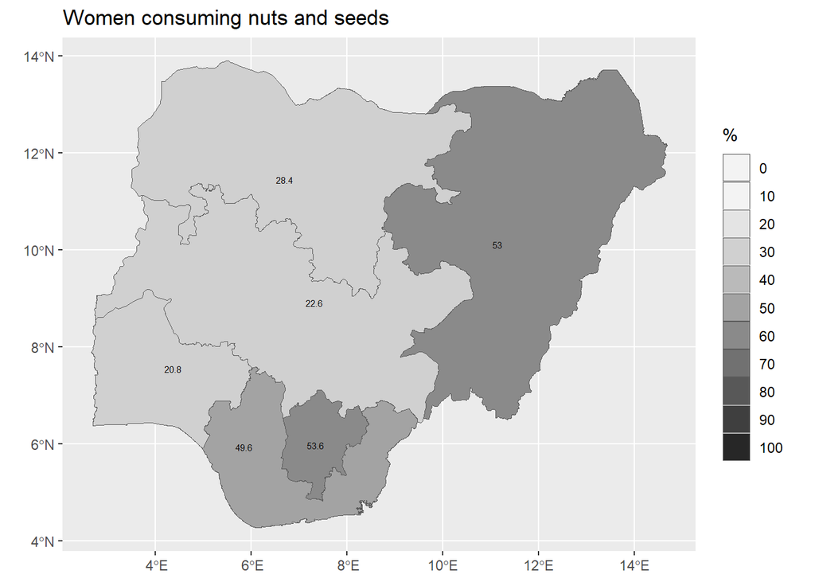

```r
ggplot(vect_gpz_geo_GHS) +
  geom_spatvector(aes(fill = nut_seeds)) +
  geom_spatvector_text(aes(label = nut_seeds), size = 2) +
  scale_fill_stepsn(
    n.breaks = 10,
    limits = c(0, 100),
    colours = hcl.colors(palette = "Grays", 10, rev = T),
    guide = "legend",
    na.value = "pink",
    labels = scales::comma
  ) +
  labs(title = "Women consuming nuts and seeds", fill = "%") +
  theme(
    plot.title = element_markdown(),
    legend.title = element_markdown(),
    axis.title = element_blank()
  )
```

### Leafy dark green vegetables (GHS, 2024)

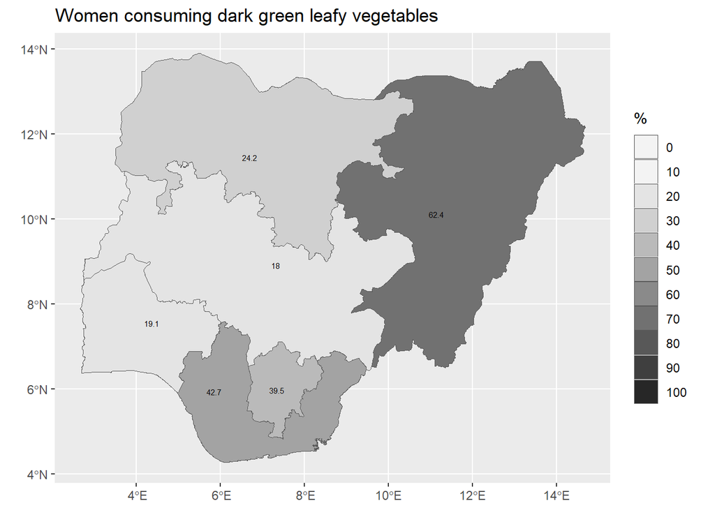

```r
ggplot(vect_gpz_geo_GHS) +
  geom_spatvector(aes(fill = greens)) +
  geom_spatvector_text(aes(label = greens), size = 2) +
  scale_fill_stepsn(
    n.breaks = 10,
    limits = c(0, 100),
    colours = hcl.colors(palette = "Grays", 10, rev = T),
    guide = "legend",
    na.value = "pink",
    labels = scales::comma
  ) +
  labs(title = "Women consuming dark green leafy vegetables", fill = "%") +
  theme(
    plot.title = element_markdown(),
    legend.title = element_markdown(),
    axis.title = element_blank()
  )
```

### Other vegetables (GHS, 2024)

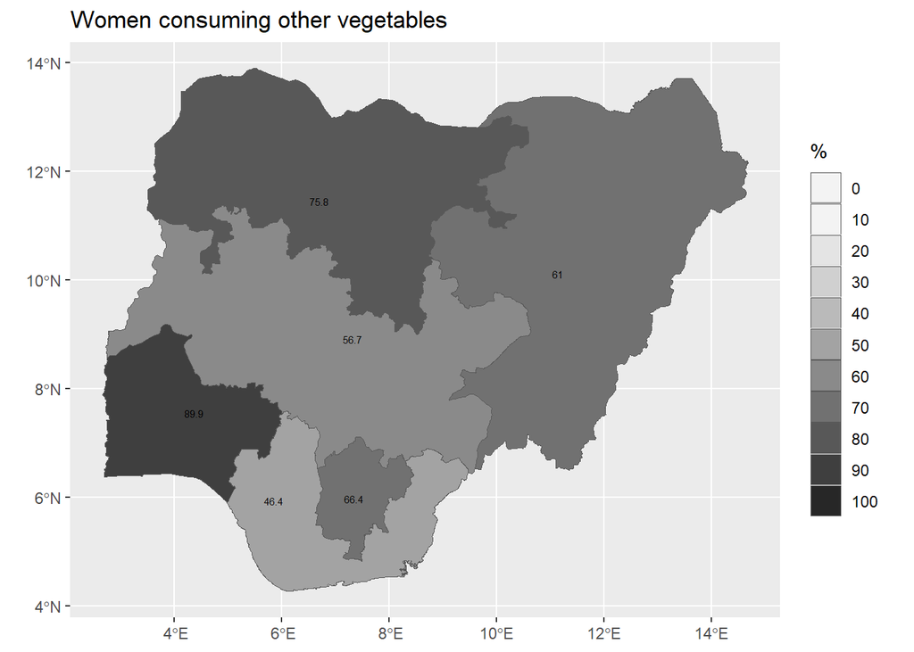

```r
ggplot(vect_gpz_geo_GHS) +
  geom_spatvector(aes(fill = veg_oth)) +
  geom_spatvector_text(aes(label = veg_oth), size = 2) +
  scale_fill_stepsn(
    n.breaks = 10,
    limits = c(0, 100),
    colours = hcl.colors(palette = "Grays", 10, rev = T),
    guide = "legend",
    na.value = "pink",
    labels = scales::comma
  ) +
  labs(title = "Women consuming other vegetables", fill = "%") +
  theme(
    plot.title = element_markdown(),
    legend.title = element_markdown(),
    axis.title = element_blank()
  )
```

### Other fruits (GHS, 2024)

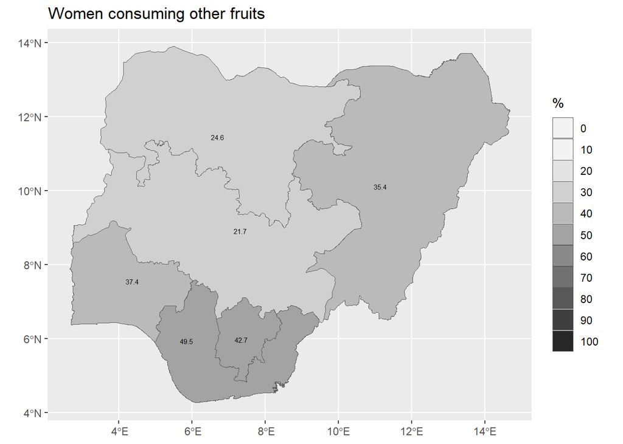

```r
ggplot(vect_gpz_geo_GHS) +
  geom_spatvector(aes(fill = fru_oth)) +
  geom_spatvector_text(aes(label = fru_oth), size = 2) +
  scale_fill_stepsn(
    n.breaks = 10,
    limits = c(0, 100),
    colours = hcl.colors(palette = "Grays", 10, rev = T),
    guide = "legend",
    na.value = "pink",
    labels = scales::comma
  ) +
  labs(title = "Women consuming other fruits", fill = "%") +
  theme(
    plot.title = element_markdown(),
    legend.title = element_markdown(),
    axis.title = element_blank()
  )
```

### Conclusion

Many different food products contribute to micro nutrient intake. The NFCMS highlights the three crops biofortified with Pro-Vitamin A: yellow cassava, orange flesh sweet potato and yellow maize.

The section above shows the proportion of women in the GHS data from 2023/24 consuming non-staple food products, but which are often good sources of micro nutrients.

# Inadequate intake of protein and micro-nutrients

The NFCMS provides data on the intake of protein and micro-nutrients, and also gives information on the prevalence of deficient intake, measured as the percentage of respondents who had a usual intake below the Estimated Average Requirements (EAR).

## Total Protein deficient intake

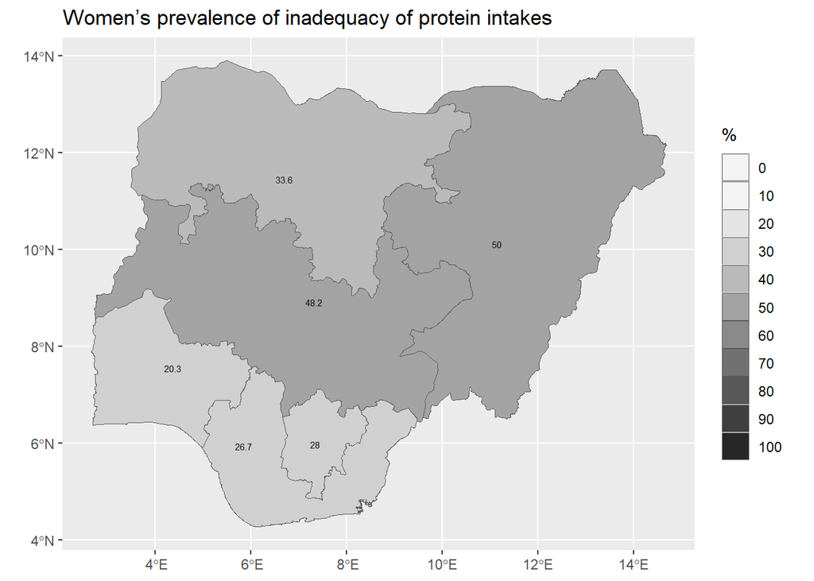

```r
ggplot(vect_gpz_geo_NFCMS) +
  geom_spatvector(aes(fill = PROT_DEF_W_46)) +
  geom_spatvector_text(aes(label = PROT_DEF_W_46), size = 2) +
  scale_fill_stepsn(
    n.breaks = 10,
    limits = c(0, 100),
    colours = hcl.colors(palette = "Grays", 10, rev = T),
    guide = "legend",
    na.value = "pink",
    labels = scales::comma
  ) +
  labs(title = "Women's prevalence of inadequacy of protein intakes", fill = "%") +
  theme(
    plot.title = element_markdown(),
    legend.title = element_markdown(),
    axis.title = element_blank()
  )
```

## Calcium deficient intake

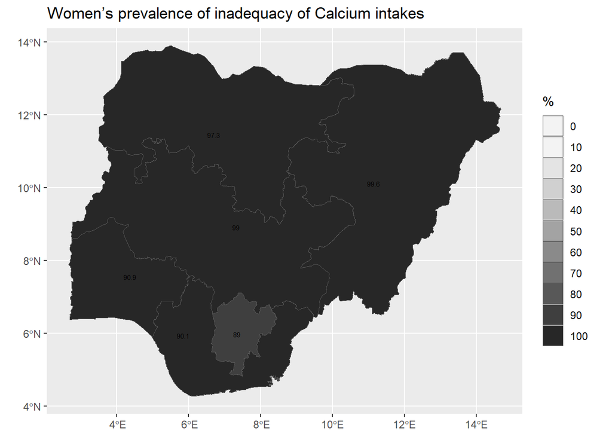

```r
ggplot(vect_gpz_geo_NFCMS) +
  geom_spatvector(aes(fill = CALC_IN_DEF_W_68)) +
  geom_spatvector_text(aes(label = CALC_IN_DEF_W_68), size = 2) +
  scale_fill_stepsn(
    n.breaks = 10,
    limits = c(0, 100),
    colours = hcl.colors(palette = "Grays", 10, rev = T),
    guide = "legend",
    na.value = "pink",
    labels = scales::comma
  ) +
  labs(title = "Women's prevalence of inadequacy of Calcium intakes", fill = "%") +
  theme(
    plot.title = element_markdown(),
    legend.title = element_markdown(),
    axis.title = element_blank()
  )
```

## Iron deficient intake

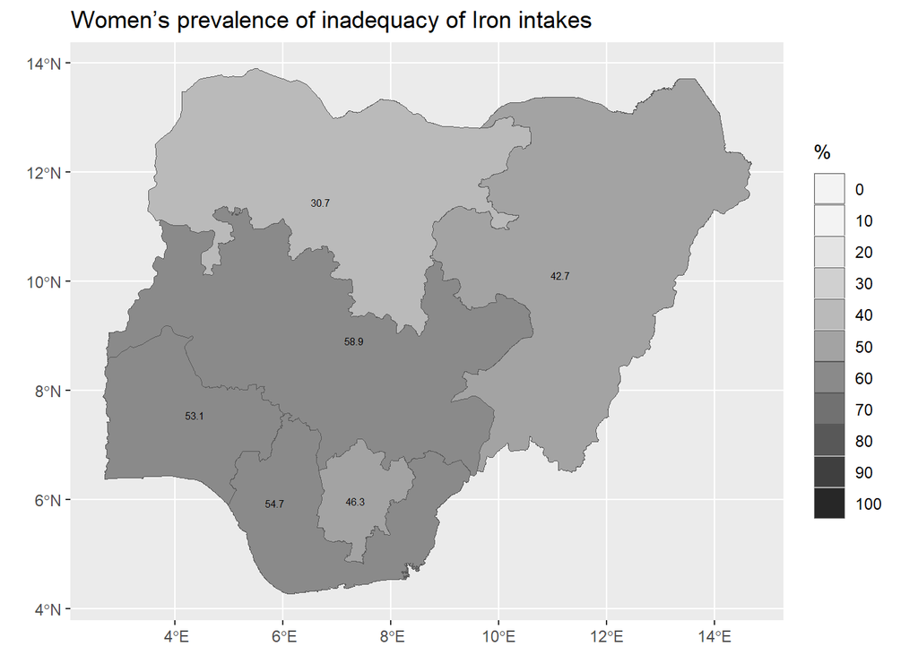

```r
ggplot(vect_gpz_geo_NFCMS) +
  geom_spatvector(aes(fill = IRON_IN_DEF_W_72)) +
  geom_spatvector_text(aes(label = IRON_IN_DEF_W_72), size = 2) +
  scale_fill_stepsn(
    n.breaks = 10,
    limits = c(0, 100),
    colours = hcl.colors(palette = "Grays", 10, rev = T),
    guide = "legend",
    na.value = "pink",
    labels = scales::comma
  ) +
  labs(title = "Women's prevalence of inadequacy of Iron intakes", fill = "%") +
  theme(
    plot.title = element_markdown(),
    legend.title = element_markdown(),
    axis.title = element_blank()
  )
```

## Zinc deficient intake

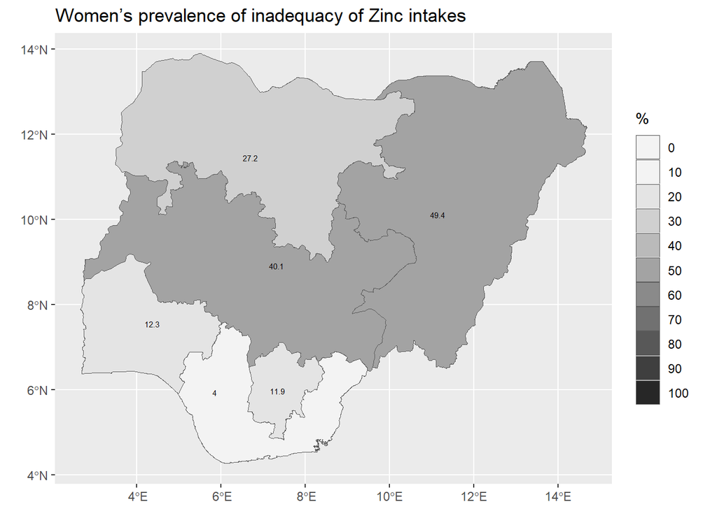

```r
ggplot(vect_gpz_geo_NFCMS) +
  geom_spatvector(aes(fill = ZINC_IN_DEF_W_76)) +
  geom_spatvector_text(aes(label = ZINC_IN_DEF_W_76), size = 2) +
  scale_fill_stepsn(
    n.breaks = 10,
    limits = c(0, 100),
    colours = hcl.colors(palette = "Grays", 10, rev = T),
    guide = "legend",
    na.value = "pink",
    labels = scales::comma
  ) +
  labs(title = "Women's prevalence of inadequacy of Zinc intakes", fill = "%") +
  theme(
    plot.title = element_markdown(),
    legend.title = element_markdown(),
    axis.title = element_blank()
  )
```

## Vitamin A deficient intake

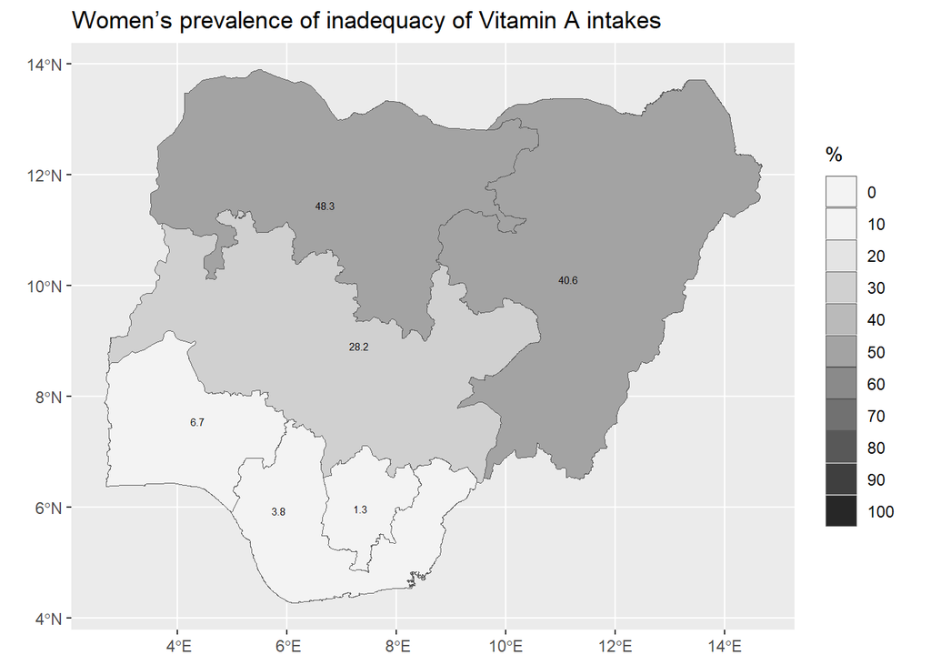

```r
ggplot(vect_gpz_geo_NFCMS) +
  geom_spatvector(aes(fill = VITA_IN_DEF_W_80)) +
  geom_spatvector_text(aes(label = VITA_IN_DEF_W_80), size = 2) +
  scale_fill_stepsn(
    n.breaks = 10,
    limits = c(0, 100),
    colours = hcl.colors(palette = "Grays", 10, rev = T),
    guide = "legend",
    na.value = "pink",
    labels = scales::comma
  ) +
  labs(title = "Women's prevalence of inadequacy of Vitamin A intakes", fill = "%") +
  theme(
    plot.title = element_markdown(),
    legend.title = element_markdown(),
    axis.title = element_blank()
  )
```

## Vitamin C deficient intake

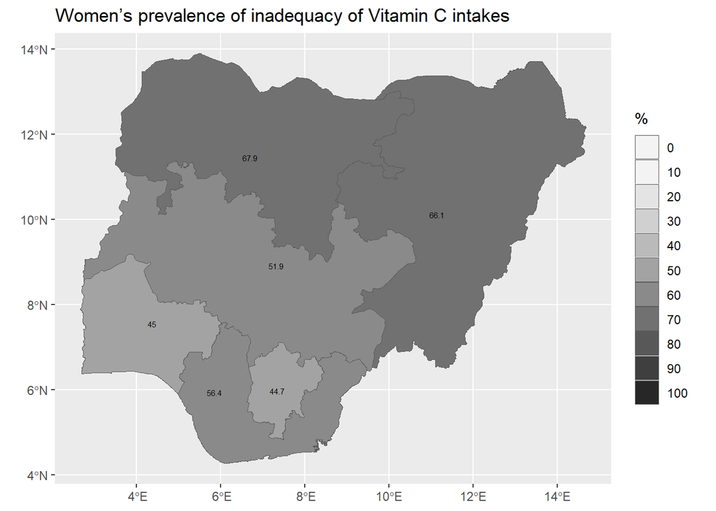

```r
ggplot(vect_gpz_geo_NFCMS) +
  geom_spatvector(aes(fill = VITC_IN_DEF_W_84)) +
  geom_spatvector_text(aes(label = VITC_IN_DEF_W_84), size = 2) +
  scale_fill_stepsn(
    n.breaks = 10,
    limits = c(0, 100),
    colours = hcl.colors(palette = "Grays", 10, rev = T),
    guide = "legend",
    na.value = "pink",
    labels = scales::comma
  ) +
  labs(title = "Women's prevalence of inadequacy of Vitamin C intakes", fill = "%") +
  theme(
    plot.title = element_markdown(),
    legend.title = element_markdown(),
    axis.title = element_blank()
  )
```

## Vitamin B1 deficient intake

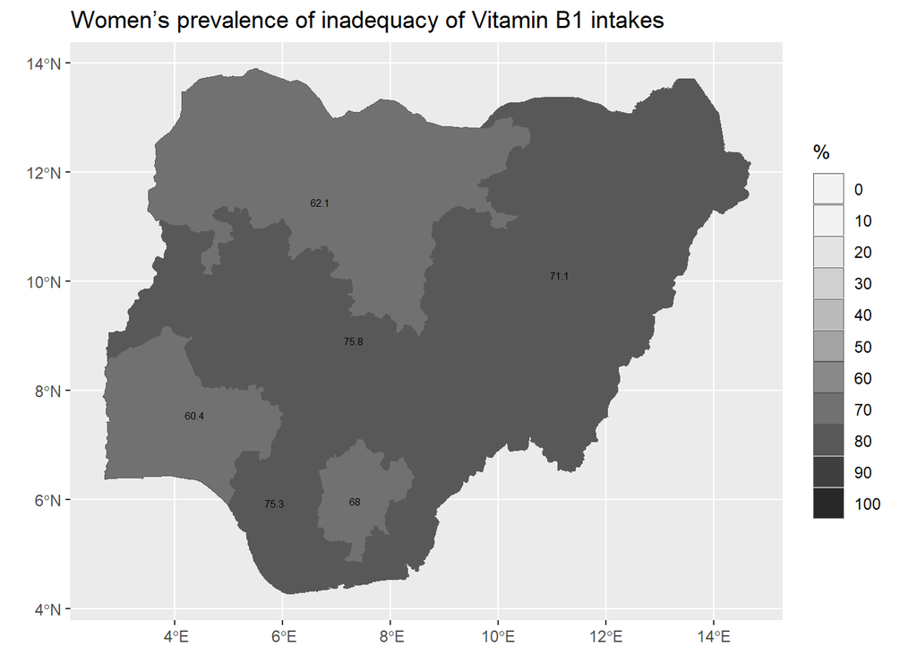

```r
ggplot(vect_gpz_geo_NFCMS) +
  geom_spatvector(aes(fill = VITB1_IN_DEF_W_88)) +
  geom_spatvector_text(aes(label = VITB1_IN_DEF_W_88), size = 2) +
  scale_fill_stepsn(
    n.breaks = 10,
    limits = c(0, 100),
    colours = hcl.colors(palette = "Grays", 10, rev = T),
    guide = "legend",
    na.value = "pink",
    labels = scales::comma
  ) +
  labs(title = "Women's prevalence of inadequacy of Vitamin B1 intakes", fill = "%") +
  theme(
    plot.title = element_markdown(),
    legend.title = element_markdown(),
    axis.title = element_blank()
  )
```

## Vitamin B2 deficient intake

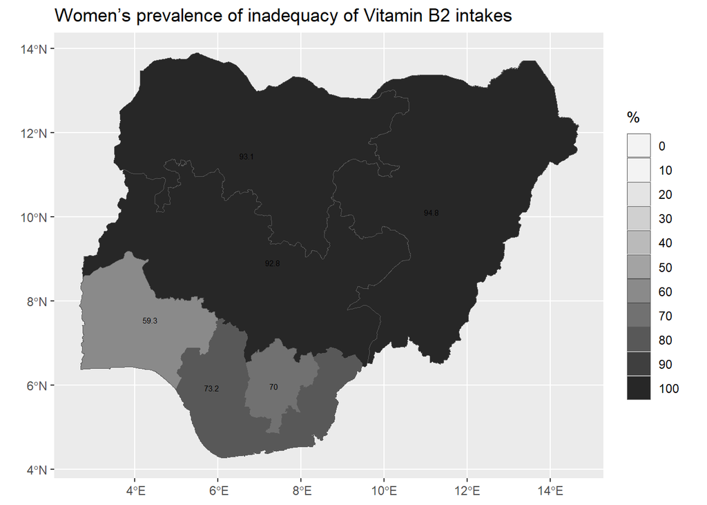

```r
ggplot(vect_gpz_geo_NFCMS) +
  geom_spatvector(aes(fill = VITB2_IN_DEF_W_92)) +
  geom_spatvector_text(aes(label = VITB2_IN_DEF_W_92), size = 2) +
  scale_fill_stepsn(
    n.breaks = 10,
    limits = c(0, 100),
    colours = hcl.colors(palette = "Grays", 10, rev = T),
    guide = "legend",
    na.value = "pink",
    labels = scales::comma
  ) +
  labs(title = "Women's prevalence of inadequacy of Vitamin B2 intakes", fill = "%") +
  theme(
    plot.title = element_markdown(),
    legend.title = element_markdown(),
    axis.title = element_blank()
  )
```

## Vitamin B9 deficient intake

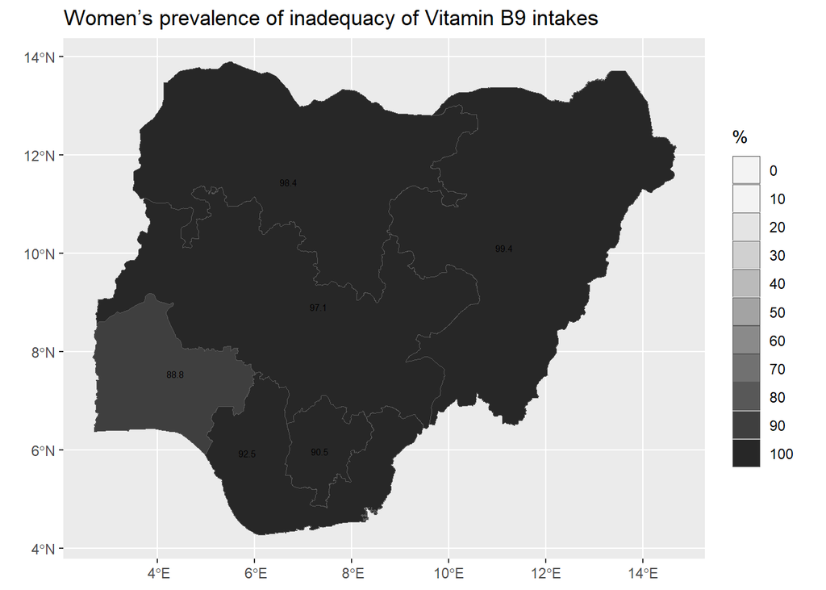

```r
ggplot(vect_gpz_geo_NFCMS) +
  geom_spatvector(aes(fill = VITB9_IN_DEF_W_96)) +
  geom_spatvector_text(aes(label = VITB9_IN_DEF_W_96), size = 2) +
  scale_fill_stepsn(
    n.breaks = 10,
    limits = c(0, 100),
    colours = hcl.colors(palette = "Grays", 10, rev = T),
    guide = "legend",
    na.value = "pink",
    labels = scales::comma
  ) +
  labs(title = "Women's prevalence of inadequacy of Vitamin B9 intakes", fill = "%") +
  theme(
    plot.title = element_markdown(),
    legend.title = element_markdown(),
    axis.title = element_blank()
  )
```

## Vitamin B12 deficient intake

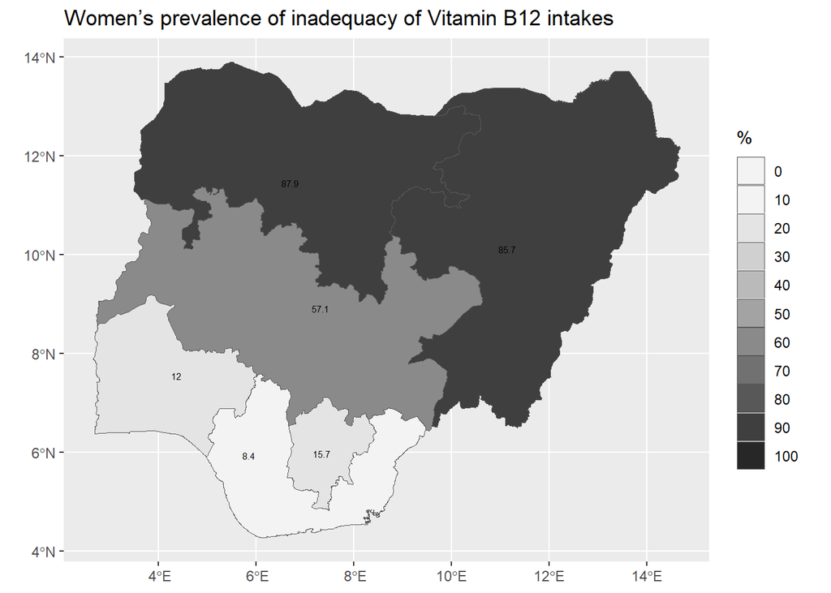

```r
ggplot(vect_gpz_geo_NFCMS) +
  geom_spatvector(aes(fill = VITB12_IN_DEF_W_100)) +
  geom_spatvector_text(aes(label = VITB12_IN_DEF_W_100), size = 2) +
  scale_fill_stepsn(
    n.breaks = 10,
    limits = c(0, 100),
    colours = hcl.colors(palette = "Grays", 10, rev = T),
    guide = "legend",
    na.value = "pink",
    labels = scales::comma
  ) +
  labs(title = "Women's prevalence of inadequacy of Vitamin B12 intakes", fill = "%") +
  theme(
    plot.title = element_markdown(),
    legend.title = element_markdown(),
    axis.title = element_blank()
  )
```

## References

Federal Government of Nigeria (FGoN), and International Institute of Tropical Agriculture (IITA). 2024. *National Food Consumption and Micronutrient Survey 2021. Final Report.* FGoN and IITA.

National Bureau of Statistics (NBS). 2024. *Nigeria General Household Survey-Panel (Wave 5) 2023/2024: Tracking Nigerian Households to Understand Their Resilience Over Time*.